# Détection de faux billets

*Projet réalisé dans le cadre de ma formation Openclassrooms*

### Mise en situation

En tant que consultant Data Analyst au sein de l'Organisation nationale de lutte contre le faux-monnayage (ONCFM), il vous est demandé de mettre en place une modélisation qui serait capable d'identifier automatiquement les vrais des faux billets.

### Données brutes

- billets.csv (contient les dimensions de 1500 billets)

### Étapes

- Nettoyage et analyse descriptive des données
- Test de différentes méthodes de prédiction pour déterminer la nature d'un billet
- Mise en forme du modèle de prédiction retenu dans un Notebook dédié

### Compétences

- Réaliser une analyse prédictive
- Réaliser une régression logistique
- Réaliser une régression linéaire
- Opérer des classifications automatiques pour partitionner les données

# Sommaire

- Importation des librairies
- Importation des données
- Analyse descriptive
- Traitement des valeurs manquantes
  - Imputation par la moyenne
  - Régression linéaire simple
  - Régression linéaire multiple
  - KNeighborsRegressor
- Modélisation
  - Préparations des données
  - Régression logistique
  - K-means
  - RandomForestClassifier
  - KNeighborsClassifier
- Exportation des données
- Conclusion

# Importation des librairies

```python
# Manipulation des données
import pandas as pd
import numpy as np

# Représentation graphique
import matplotlib.pyplot as plt
import seaborn as sns
%matplotlib inline

import math

# Analyse en composante principale
from sklearn.decomposition import PCA

# Découpage du jeu de données
from sklearn.model_selection import train_test_split

# Calcul de la RMSE
from sklearn.metrics import mean_squared_error

# Régression linéaire
import statsmodels.api as sm
import statsmodels.formula.api as smf

from statsmodels.stats.outliers_influence import variance_inflation_factor
import statsmodels.stats.api as sms

# k-nearest neighbors
from sklearn.neighbors import KNeighborsRegressor
from sklearn.neighbors import KNeighborsClassifier

from sklearn.model_selection import GridSearchCV

# Régression logistique
from sklearn.linear_model import LogisticRegression

# Clustering K-means
from sklearn import cluster, metrics

# Random Forest classification
from sklearn.ensemble import RandomForestClassifier

# Calcul et affichage courbe ROC
from sklearn.metrics import roc_auc_score
from sklearn.metrics import roc_curve
from statistics import mean

# Matrice de confusion
from sklearn.metrics import confusion_matrix, accuracy_score, precision_score, recall_score, f1_score, make_scorer

# Tests statistiques
from scipy.stats import t, shapiro, kstest
```

# Importation des données

```python
# Importation du fichier mis à notre disposition par l'ONCFM
billets = pd.read_csv("Data/billets.csv", sep = ';')
```

# Analyse descriptive

```python
# Affichage du nombre de lignes et de colonnes
print("Le dataframe est composé de", billets.shape[0], "lignes et", billets.shape[1], "colonnes.")
billets.head(5)
```

```
Le dataframe est composé de 1500 lignes et 7 colonnes.
```

|  | is_genuine | diagonal | height_left | height_right | margin_low | margin_up | length |
| --- | --- | --- | --- | --- | --- | --- | --- |
| 0 | True | 171.81 | 104.86 | 104.95 | 4.52 | 2.89 | 112.83 |
| 1 | True | 171.46 | 103.36 | 103.66 | 3.77 | 2.99 | 113.09 |
| 2 | True | 172.69 | 104.48 | 103.50 | 4.40 | 2.94 | 113.16 |
| 3 | True | 171.36 | 103.91 | 103.94 | 3.62 | 3.01 | 113.51 |
| 4 | True | 171.73 | 104.28 | 103.46 | 4.04 | 3.48 | 112.54 |

```python
# On affiche les informations sur le dataframe billets
billets.info()
print(" ")

# On regarde s'il y a des doublons au niveau des lignes
print("Il y a", billets.duplicated().sum(), "lignes en doubles dans le dataframe.")
print(" ")

# On affiche le compte des valeurs uniques dans chaque colonne
print("Nombre de valeurs uniques par colonne:")
billets.nunique()
```

```
<class 'pandas.core.frame.DataFrame'>
RangeIndex: 1500 entries, 0 to 1499
Data columns (total 7 columns):
 #   Column        Non-Null Count  Dtype
---  ------        --------------  -----
 0   is_genuine    1500 non-null   bool
 1   diagonal      1500 non-null   float64
 2   height_left   1500 non-null   float64
 3   height_right  1500 non-null   float64
 4   margin_low    1463 non-null   float64
 5   margin_up     1500 non-null   float64
 6   length        1500 non-null   float64
dtypes: bool(1), float64(6)
memory usage: 71.9 KB

Il y a 0 lignes en doubles dans le dataframe.

Nombre de valeurs uniques par colonne:
```

```
is_genuine        2
diagonal        159
height_left     155
height_right    170
margin_low      285
margin_up       123
length          336
dtype: int64
```

Il y a 37 valeurs manquantes dans la colonne margin_low (1463 valeurs sur 1500).

### Répartition des billets

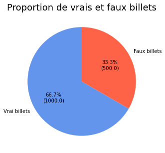

```python
# On compte les différentes valeurs de la colonne "is_genuine"
comptage = billets["is_genuine"].value_counts()

# On définit une fonction qui permet d'afficher le nombre sur le diagramme.
def func(pct):
    total_values = round(comptage.sum())
    return "{:.1f}%\n({})".format(pct, round(pct*total_values/100, 0))

plt.figure(figsize=(10, 5))
nature = [comptage[1], comptage[0]]
labels = 'Vrai billets','Faux billets'
colors = 'cornflowerblue', 'tomato'
plt.title("Proportion de vrais et faux billets", fontsize=18)
plt.pie(nature, labels = labels, autopct = func, colors = colors, startangle = 90)
plt.show()
```

Notre jeu de données est composé de 1000 vrais billets et 500 faux billets.

### Recherche d'outliers et variance

```python
# Informations sur les données numériques du dataframe
billets.describe()
```

|  | diagonal | height_left | height_right | margin_low | margin_up | length |
| --- | --- | --- | --- | --- | --- | --- |
| count | 1500.000000 | 1500.000000 | 1500.000000 | 1463.000000 | 1500.000000 | 1500.00000 |
| mean | 171.958440 | 104.029533 | 103.920307 | 4.485967 | 3.151473 | 112.67850 |
| std | 0.305195 | 0.299462 | 0.325627 | 0.663813 | 0.231813 | 0.87273 |
| min | 171.040000 | 103.140000 | 102.820000 | 2.980000 | 2.270000 | 109.49000 |
| 25% | 171.750000 | 103.820000 | 103.710000 | 4.015000 | 2.990000 | 112.03000 |
| 50% | 171.960000 | 104.040000 | 103.920000 | 4.310000 | 3.140000 | 112.96000 |
| 75% | 172.170000 | 104.230000 | 104.150000 | 4.870000 | 3.310000 | 113.34000 |
| max | 173.010000 | 104.880000 | 104.950000 | 6.900000 | 3.910000 | 114.44000 |

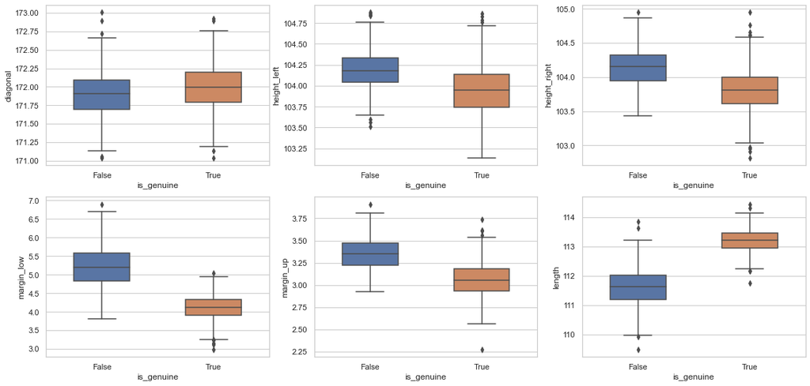

```python
# Représentation de la distribution des valeurs pour chaques variables
plt.figure(figsize=(19, 14))
plt.title("Distribution de valeurs des variables")
sns.set(style="whitegrid")

plt.subplot(331)
sns.boxplot(data=billets, x="is_genuine", y="diagonal", width=0.5)

plt.subplot(332)
sns.boxplot(data=billets, x="is_genuine", y="height_left", width=0.5)

plt.subplot(333)
sns.boxplot(data=billets, x="is_genuine", y="height_right", width=0.5)

plt.subplot(334)
sns.boxplot(data=billets, x="is_genuine", y="margin_low", width=0.5)

plt.subplot(335)
sns.boxplot(data=billets, x="is_genuine", y="margin_up", width=0.5)

plt.subplot(336)
sns.boxplot(data=billets, x="is_genuine", y="length", width=0.5)

plt.show()
```

```python
# Calcul des variances
billets.var()
```

```
is_genuine      0.222370
diagonal        0.093144
height_left     0.089677
height_right    0.106033
margin_low      0.440647
margin_up       0.053737
length          0.761657
dtype: float64
```

Il y des outliers mais ceux-ci ne sont pas trop importants et les valeurs correspondantes ne sont pas aberrantes dans notre contexte, on décide de les garder dans le jeu de données.

On observe pour les boxplot de "length" et "margin_low" des différences plus importantes en fonction de la nature des billets.

Certaines des variables ont des valeurs supérieures à 100 (diagonal, height_left, height_right et length) et d'autres ont des valeurs inférieures à 10 (margin_low, margin_up). Ces différences ne sont pas dues aux unités, toutes nos variables sont en millimètres. De plus, même si les valeurs sont dans des plages différentes, les tailles des plages de valeurs sont similaires entre les variables (variances similaires).  
**À partir de ces observations, nous avons décidé de ne pas standardiser nos données.**

```python
# On crée un dataframe sans les valeurs manquantes pour l'analyse en composantes principales
df_billets = billets.dropna()
print(df_billets.shape)
```

```
(1463, 7)
```

### Analyse en composantes principales

```python
# On enlève la variable binaire is_genuine
df_acp = df_billets.drop(columns=['is_genuine'])
```

```python
df_acp.head()
```

|  | diagonal | height_left | height_right | margin_low | margin_up | length |
| --- | --- | --- | --- | --- | --- | --- |
| 0 | 171.81 | 104.86 | 104.95 | 4.52 | 2.89 | 112.83 |
| 1 | 171.46 | 103.36 | 103.66 | 3.77 | 2.99 | 113.09 |
| 2 | 172.69 | 104.48 | 103.50 | 4.40 | 2.94 | 113.16 |
| 3 | 171.36 | 103.91 | 103.94 | 3.62 | 3.01 | 113.51 |
| 4 | 171.73 | 104.28 | 103.46 | 4.04 | 3.48 | 112.54 |

```python
# On choisit le maximum de variables synthétiques possibles pour commencer
n_components = 6

# On instancie
pca = PCA(n_components= n_components)

# On entraine
pca.fit(df_acp.values)

# On affiche la variance expliquée par chaque composante
print(pca.explained_variance_ratio_)
```

```
[0.69275733 0.11893861 0.06268825 0.05447595 0.04724225 0.02389761]
```

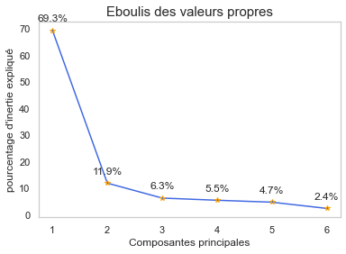

```python
# On enregistre les valeurs de variance expliquée par chaque composante
scree = (pca.explained_variance_ratio_*100).round(2)

# On stocke la liste de nos composantes qui sera l'abscisse de notre graphique
x_list = range(1, n_components+1)
X_list = list(x_list)

# Représentation du pourcentage d'inertie expliqué pour chaque composante
plt.plot(x_list, scree,c="royalblue",marker='*', markeredgecolor= "orange")
plt.xlabel("Composantes principales")
plt.ylabel("pourcentage d'inertie expliqué")
plt.title("Eboulis des valeurs propres", fontsize = 15)

# Affichage des pourcentages sur le graph
for x,y in zip(x_list,scree):

    label = "{:.1f}%".format(y)

    plt.annotate(label,
                 (x,y),
                 textcoords="offset points", # position du texte
                 xytext=(0,10), # distance du texte au points (x,y)
                 ha='center')

plt.grid(False)
plt.show(block=False)
```

On observe un coude pour 2 composantes principales, ensuite le pourcentage d'inertie (ou de variance) expliqué diminue plus lentement. On relance une ACP pour 2 composantes principales.

```python
# On relance une PCA pour 2 composantes principales
n_components = 2

# On instancie
pca = PCA(n_components= n_components)

# On entraine
pca.fit(df_acp)

# Coordonnées des variables sur le premier plan factoriel F1-F2
pcs = pca.components_
pcs
```

```
array([[-0.03546904,  0.10675636,  0.14885979,  0.54175733,  0.12455708,
        -0.81004341],
       [-0.03703737,  0.04261251,  0.06377514,  0.82067501, -0.02078879,
         0.56462863]])
```

### Cercle des corrélations

Nous pouvons maintenant tracer le cercle des corrélations et étudier les relations entre les variables initiales et nos composantes principales.

#### Création d'une fonction qui crée et affiche le cercle

```python
def cercle_corr(axe1, axe2):
    fig, ax = plt.subplots(figsize=(9, 8))
    for i in range(0, pcs.shape[1]):
        ax.arrow(0,
                 0,  # La flèche commence à l'origine
                 pcs[axe1, i],  #0 for PC1
                 pcs[axe2, i],  #1 for PC2
                 head_width=0.07,
                 head_length=0.07,
                 width=0.02,              )

    # On affiche le nom des variables
        plt.text(pcs[axe1, i] + 0.05,
                 pcs[axe2, i] + 0.05,
                 df_acp.columns[i])

    # Affichage des lignes horizontales et verticales
    plt.plot([-1, 1], [0, 0], color='grey', ls='--')
    plt.plot([0, 0], [-1, 1], color='grey', ls='--')


    # Nom des axes, avec le pourcentage d'inertie expliqué
    plt.xlabel('F{} ({}%)'.format(axe1+1, round(100*pca.explained_variance_ratio_[axe1],1)), fontsize=14)
    plt.ylabel('F{} ({}%)'.format(axe2+1, round(100*pca.explained_variance_ratio_[axe2],1)), fontsize=14)

    plt.title(f"Cercle des corrélations (F{axe1+1} et F{axe2+1})", fontsize=15)

    # On ajoute le cercle unitaire
    an = np.linspace(0, 2 * np.pi, 100)
    plt.plot(np.cos(an), np.sin(an))
    plt.axis('equal')
    plt.grid(False)
    plt.show(block=False)
```

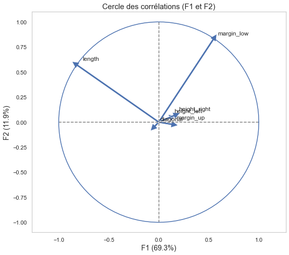

```python
# Cercle plan F1-F2
cercle_corr(0,1)
```

Les variables "length" et "margin_low" sont complètement représentées sur le plan F1-F2.  
"length" est la variable la plus corrélée (négativement) à F1 et elle est corrélée positivement à F2.  
"margin_low" est la plus corrélée (positivement) à F2 et elle est corrélée positivement à F1.

### Projection des individus

```python
# On applique la réduction de dimension à nos données
X_proj = pca.transform(df_acp.values)

# On converti en dataframe
X_proj = pd.DataFrame(X_proj, columns = ["F1", "F2"], index = df_acp.index)

# On ajoute une colonne avec les labels True et False pour chaque individu
X_proj["is_genuine"] = df_billets["is_genuine"]
X_proj.head()
```

|  | F1 | F2 | is_genuine |
| --- | --- | --- | --- |
| 0 | 0.106778 | 0.227485 | True |
| 1 | -0.837445 | -0.376522 | True |
| 2 | -0.506946 | 0.173032 | True |
| 3 | -1.152492 | -0.217898 | True |
| 4 | -0.125746 | -0.459224 | True |

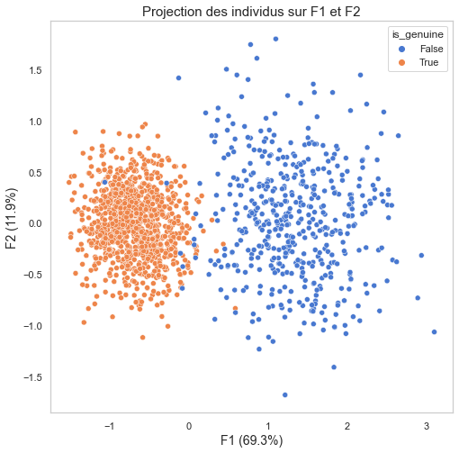

```python
# On représente nos individus sur le premier plan factoriel
plt.figure(figsize=(8, 8))

plt.title("Projection des individus sur F1 et F2", fontsize=15)

# nom des axes, avec le pourcentage d'inertie expliqué
plt.xlabel('F{} ({}%)'.format(1, round(100*pca.explained_variance_ratio_[0],1)), fontsize= 14)
plt.ylabel('F{} ({}%)'.format(2, round(100*pca.explained_variance_ratio_[1],1)), fontsize= 14)

sns.scatterplot(data= X_proj, x="F1", y="F2", hue="is_genuine", palette="muted") # Nuage des individus
plt.grid(False)

plt.show()
```

On observe que les vrais et faux billets se distinguent selon l'axe F1, les vrais billets ont tendance à avoir des valeurs négatives sur F1 et les faux des valeurs positives. D'après le cercle des corrélations la variable length est négativement corrélée à F1 et margin_low positivement, les vrais billets auront donc tendance à avoir des valeurs de length plus grandes que les faux billets et des valeurs de margin_low plus petites.

# Traitement des valeurs manquantes

Nous avons des valeurs manquantes dans le dataset original, nous allons tester plusieurs méthodes pour déterminer ces valeurs. Nous commencerons par diviser notre jeu de données en deux parties, l'une d'entraînement (train) et l'autre de test (test). Pour comparer les erreurs des différents modèles prédictifs, nous calculerons pour chacun la racine de l'erreur quadratique moyenne (RMSE pour Root-Mean-Square Error) sur le test set (plus la valeur est proche de 0, meilleur est le modèle évalué en terme d'exactitude).

### Découpage du jeu de données

```python
df_billets.head()
```

|  | is_genuine | diagonal | height_left | height_right | margin_low | margin_up | length |
| --- | --- | --- | --- | --- | --- | --- | --- |
| 0 | True | 171.81 | 104.86 | 104.95 | 4.52 | 2.89 | 112.83 |
| 1 | True | 171.46 | 103.36 | 103.66 | 3.77 | 2.99 | 113.09 |
| 2 | True | 172.69 | 104.48 | 103.50 | 4.40 | 2.94 | 113.16 |
| 3 | True | 171.36 | 103.91 | 103.94 | 3.62 | 3.01 | 113.51 |
| 4 | True | 171.73 | 104.28 | 103.46 | 4.04 | 3.48 | 112.54 |

```python
# On découpe notre dataframe en une partie d'entrainement et une de test
train, test = train_test_split(df_billets, test_size=0.2, random_state=42)

# On affiche le nombre de lignes et colonnes
print(f"""Le train set est composé de {train.shape[0]} lignes et {train.shape[1]} colonnes.
Le test set est composé de {test.shape[0]} lignes et {test.shape[1]} colonnes.""")
```

```
Le train set est composé de 1170 lignes et 7 colonnes.
Le test set est composé de 293 lignes et 7 colonnes.
```

## Imputation par la moyenne

Pour cette première méthode, on détermine les valeurs manquantes en faisant la moyenne des valeurs de margin_low du train set.

```python
test_mean = test.copy()

# Calcul de margin_low moy
mean_all = round(train["margin_low"].mean(), 2)

# On ajoute au test set une colonne avec la moyenne de margin_low, calculée à partir des données d'entrainement
test_mean["margin_low_pred"]=mean_all
test_mean.head()
```

|  | is_genuine | diagonal | height_left | height_right | margin_low | margin_up | length | margin_low_pred |
| --- | --- | --- | --- | --- | --- | --- | --- | --- |
| 1208 | False | 171.96 | 104.38 | 103.82 | 5.19 | 3.32 | 111.68 | 4.48 |
| 178 | True | 171.79 | 104.57 | 104.04 | 4.26 | 3.15 | 113.46 | 4.48 |
| 281 | True | 171.99 | 103.90 | 104.21 | 4.18 | 3.07 | 113.01 | 4.48 |
| 561 | True | 172.25 | 103.71 | 103.97 | 3.93 | 3.00 | 113.38 | 4.48 |
| 891 | True | 172.16 | 103.63 | 103.59 | 4.25 | 3.38 | 113.58 | 4.48 |

### Calcul de la RMSE

On calcul la racine de l'erreur quadratique moyenne à l'aide de la formule suivante:

RMSE = $\sqrt{\frac{1}{n}\sum_{i=0}^{n-1} (pred_i-obs_i)^2}$

n: nombre de points dans le jeu de test  
pred: valeur prédite par le modèle  
obs: valeur réel observée

```python
# Calcul de la RMSE
y_actual = test_mean["margin_low"]
y_predicted = test_mean["margin_low_pred"]

MSE = mean_squared_error(y_actual, y_predicted)

RMSE_mean = math.sqrt(MSE)
print("\033[1mRoot Mean Square Error:\033[0m", round(RMSE_mean, 3))
```

```
Root Mean Square Error: 0.649
```

## Régression linéaire simple

Nous cherchons à expliquer la variable margin_low à partir d'une variable explicative. Pour ce faire, nous devons déterminer les paramètres $ß_1$ et $ß_2$ de l'équation suivante:

**$Y = ß_1 + ß_2X + ε$**

Y: variable à expliquer  
X: variable explicative  
$ß_1$ et $ß_2$: paramètres inconnus  
ε: erreur du modèle

Avant de réaliser la régression, il nous faut choisir la variable explicative la plus appropriée. Pour cela, on regarde quelle variable est la plus corrélée à "margin_low".

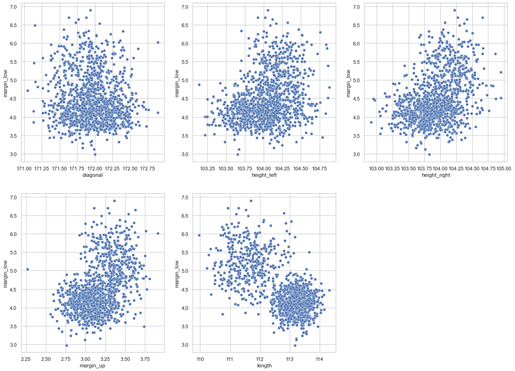

```python
# Création nuages de points entre margin_low et les autres variables
plt.figure(figsize=(19, 14))

sns.set(style="whitegrid")

plt.subplot(231)
sns.scatterplot(data=train, x="diagonal", y="margin_low")

plt.subplot(232)
sns.scatterplot(data=train, x="height_left", y="margin_low")

plt.subplot(233)
sns.scatterplot(data=train, x="height_right", y="margin_low")

plt.subplot(234)
sns.scatterplot(data=train, x="margin_up", y="margin_low")

plt.subplot(235)
sns.scatterplot(data=train, x="length", y="margin_low")

plt.show()
```

D'après les nuages de points, il semble y avoir une relation linéaire entre margtin_low et length. On analyse plus en détails en calculant les coefficients de Pearson entre les variables, ce coefficient nous renseigne sur l'intensité et le sens de la relation linéaire entre deux variables quantitatives.

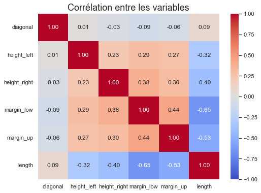

```python
# On enlève la variable "is_genuine"
train_corr = train.drop(columns=["is_genuine"])

# On affiche une heatmap de la matrice de corrélation entre variables
plt.figure(figsize=(8, 6))
sns.heatmap(train_corr.corr(method='pearson'), vmin=-1, vmax=1, annot=True, cmap="coolwarm", fmt="0.2f")
plt.title("Corrélation entre les variables", fontsize= 18)
plt.show()
```

D'après la heatmap, la variable "length" est la plus corrélée avec "margin_low", c'est une corrélation négative avec un coefficient de Pearson de -0.65.  
On choisit length comme variable explicative.

```python
# On lance la régression linéaire avec length
reg_simp = smf.ols( "margin_low~length" , data=train).fit()
print(reg_simp.summary())
```

```
                            OLS Regression Results
==============================================================================
Dep. Variable:             margin_low   R-squared:                       0.428
Model:                            OLS   Adj. R-squared:                  0.428
Method:                 Least Squares   F-statistic:                     874.1
Date:                Wed, 15 Mar 2023   Prob (F-statistic):          7.17e-144
Time:                        15:56:13   Log-Likelihood:                -859.74
No. Observations:                1170   AIC:                             1723.
Df Residuals:                    1168   BIC:                             1734.
Df Model:                           1
Covariance Type:            nonrobust
==============================================================================
                 coef    std err          t      P>|t|      [0.025      0.975]
------------------------------------------------------------------------------
Intercept     60.7050      1.902     31.922      0.000      56.974      64.436
length        -0.4990      0.017    -29.565      0.000      -0.532      -0.466
==============================================================================
Omnibus:                       86.499   Durbin-Watson:                   1.970
Prob(Omnibus):                  0.000   Jarque-Bera (JB):              118.103
Skew:                           0.613   Prob(JB):                     2.26e-26
Kurtosis:                       3.958   Cond. No.                     1.45e+04
==============================================================================

Notes:
[1] Standard Errors assume that the covariance matrix of the errors is correctly specified.
[2] The condition number is large, 1.45e+04. This might indicate that there are
strong multicollinearity or other numerical problems.
```

La p-value pour la statistique de Fischer est de 7.17e-144, c'est inférieure au niveau de test de 5%, le modèle est globalement significatif. Le R² ajusté est égal à 0.428, cela signifie que notre modèle permet d'expliquer environ 43 % de la variation de la variable Y (margin_low) et la p-value du paramètre de 'length' est inférieure à 0.05, il est donc significatif.

#### Représentation des résidus

```python
train_reg_simp = train.copy()

# On ajoute une colonne avec les résidus
train_reg_simp["residus"] = reg_simp.resid

train_reg_simp.reset_index(inplace=True)

train_reg_simp.head()
```

|  | index | is_genuine | diagonal | height_left | height_right | margin_low | margin_up | length | residus |
| --- | --- | --- | --- | --- | --- | --- | --- | --- | --- |
| 0 | 893 | True | 172.20 | 103.52 | 103.78 | 3.66 | 3.40 | 113.35 | -0.487590 |
| 1 | 1071 | False | 171.50 | 103.90 | 103.98 | 4.82 | 3.40 | 112.07 | 0.033738 |
| 2 | 260 | True | 172.27 | 103.71 | 103.64 | 4.64 | 2.67 | 113.63 | 0.632120 |
| 3 | 1097 | False | 172.51 | 104.43 | 104.17 | 5.11 | 3.08 | 111.70 | 0.139122 |
| 4 | 1224 | False | 171.74 | 104.52 | 104.23 | 5.59 | 3.61 | 112.14 | 0.838665 |

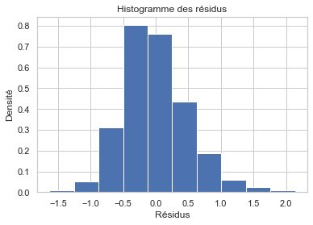

```python
# Histogramme des résidus
plt.hist(train_reg_simp['residus'], density=True)
plt.xlabel('Résidus')
plt.ylabel('Densité')
plt.title('Histogramme des résidus')
plt.show()
```

```python
# Test de normalité
print("Shapiro_test:", shapiro(train_reg_simp['residus']))
```

```
Shapiro_test: ShapiroResult(statistic=0.9792361259460449, pvalue=6.572695512852e-12)
```

La p-value pour le test de Shapiro est inférieur à 0.05, on rejette H0 qui suppose la normalité de la distribution des valeurs.

#### On teste l'homoscédasticité

On vérifie si la variance des résidus est constante.

```python
variables = reg_simp.model.exog
_, pval, __, f_pval = sms.het_breuschpagan(reg_simp.resid, variables)
print('p value test Breusch Pagan:', pval)
```

```
p value test Breusch Pagan: 1.575500230788822e-12
```

La p-value est inférieure à 5%, on rejette H0 qui suppose la constance de la variance, la variance de nos résidus n'est pas constante.

La normalité des résidus et l'homoscédasticité sont remises en cause d'après nos tests statistiques.  
Cependant en regardant l'histogramme des résidus on observe une distribution similaire à la distribution normale, assez centré en 0 et symétrique et la taille de notre échantillon est supérieure à 30 individus.  
D'après ces observations nous décidons de considérer que les prérequis sont respectés.

### Observations atypiques et influentes

On s'intéresse maintenant aux données atypiques et influentes, pour ce faire, on analyse les leviers, les résidus studentisés et la distance de Cook.

#### Calcul des leviers

Le calcul des leviers nous permet d'analyser l'atypicité des observations sur les variables explicatives.

```python
n = train.shape[0]
p = 5

analyses = pd.DataFrame({'obs':np.arange(1, n+1)})

analyses['levier'] = reg_simp.get_influence().hat_matrix_diag

seuil_levier = 2*p/n # seuil au dessus duquel l'observation est considérée comme atypique
analyses.head()
```

|  | obs | levier |
| --- | --- | --- |
| 0 | 1 | 0.001365 |
| 1 | 2 | 0.001262 |
| 2 | 3 | 0.001875 |
| 3 | 4 | 0.001915 |
| 4 | 5 | 0.001173 |

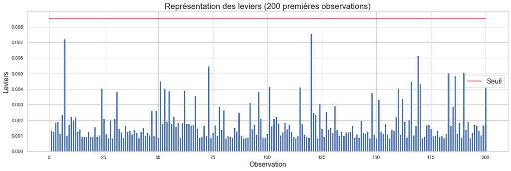

```python
# Représentation des leviers avec un diagramme barre
plt.figure(figsize=(20,6))

plt.bar(analyses['obs'][:200], analyses['levier'][:200])
plt.xlabel('Observation', fontsize=16)
plt.ylabel('Leviers', fontsize=16)

# Ajout de la ligne de seuil
plt.plot([0, 200], [seuil_levier, seuil_levier], color='r', label="Seuil")

plt.legend(prop={'size': 16})
plt.title("Représentation des leviers (200 premières observations)", fontsize=19)
plt.show()
```

```python
# On affiche les points qui dépasse le seuil
leviers = analyses.loc[analyses['levier'] > seuil_levier, :]
print(f"{leviers.shape[0]} observation a un levier qui dépasse le seuil")
```

```
1 observation a un levier qui dépasse le seuil
```

#### Calcule des résidus studentisés

Le calcul des leviers nous permet d'analyser l'atypicité des observations sur la variable à expliquer.

```python
analyses['rstudent'] = reg_simp.get_influence().resid_studentized_internal

alpha=0.05
seuil_rstudent = t.ppf(1-alpha/2,n-p-1) # observation atypique si la valeur absolue du résidu est supèrieur au seuil
```

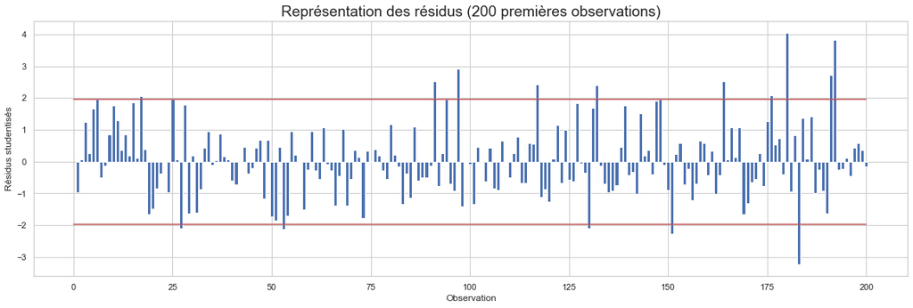

```python
# Représentation des résidus avec un diagramme barre

plt.figure(figsize=(20,6))
plt.bar(analyses['obs'][:200], analyses['rstudent'][:200])
plt.xlabel('Observation')
plt.ylabel('Résidus studentisés')
plt.plot([0, 200], [seuil_rstudent, seuil_rstudent], color='r')
plt.plot([0, 200], [-seuil_rstudent, -seuil_rstudent], color='r')
plt.title("Représentation des résidus (200 premières observations)", fontsize=19)
plt.show()
```

```python
# On affiche les résidus qui dépassent le seuils
residus = analyses.loc[(analyses['rstudent'] > seuil_rstudent) | (analyses['rstudent'] < -seuil_rstudent), :]
print(f"{residus.shape[0]} observations ont des résidus qui dépassent le seuil")
```

```
61 observations ont des résidus qui dépassent le seuil
```

#### Distance de Cook

Cette distance nous indique à quel point l'estimation des paramètres change lorsque l'un des points est retiré. Elle nous renseigne sur l'influence de chaque point (une distance élevée indique une forte influence).

```python
influence = reg_simp.get_influence().summary_frame()

influence = influence.sort_index()

influence['cooks_d'] = influence['cooks_d'].array
analyses['dcooks'] = influence['cooks_d'].values

seuil_dcook = 4/(n-p) # seuil au dessus duquel l'observation est considirée comme influente
```

```python
analyses.head()
```

|  | obs | levier | rstudent | dcooks |
| --- | --- | --- | --- | --- |
| 0 | 1 | 0.001365 | -0.966244 | 0.000022 |
| 1 | 2 | 0.001262 | 0.066854 | 0.000530 |
| 2 | 3 | 0.001875 | 1.252976 | 0.000055 |
| 3 | 4 | 0.001915 | 0.275769 | 0.000645 |
| 4 | 5 | 0.001173 | 1.661802 | 0.000450 |

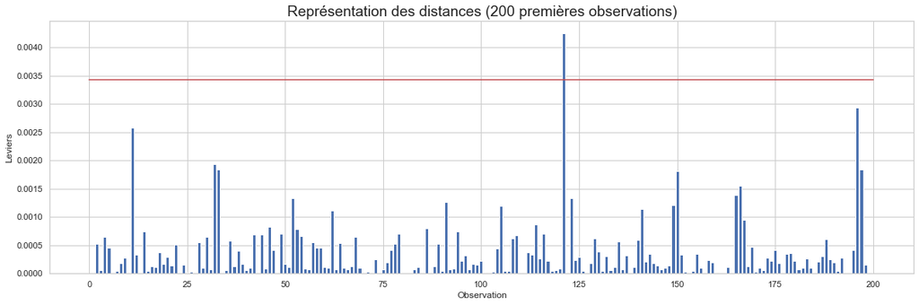

```python
# Représentation des distances de Cook avec un diagramme barre

plt.figure(figsize=(20,6))

plt.bar(analyses['obs'][:200], analyses['dcooks'][:200])

plt.xlabel('Observation')
plt.ylabel('Leviers')
plt.plot([0, 200], [seuil_dcook, seuil_dcook], color='r')
plt.title("Représentation des distances (200 premières observations)", fontsize=19)
plt.show()
```

```python
# On affiche les distances qui dépassent les seuils
cook = analyses.loc[analyses['dcooks'] > seuil_dcook, :]
print(f"{residus.shape[0]} points ont des distances de Cook qui dépassent le seuil")
```

```
61 points ont des distances de Cook qui dépassent le seuil
```

```python
# On affiche les points qui dépassent les seuils de levier, résidus et distance de Cooks
analyses.loc[(analyses["obs"].isin(leviers["obs"]))&(analyses["obs"].isin(residus["obs"]))&(analyses["obs"].isin(cook["obs"]))]
```

|  | obs | levier | rstudent | dcooks |
| --- | --- | --- | --- | --- |

**Il n'y a pas d'observation qui soit à la fois atypique et influente.**

À partir des données test, nous pouvons maintenant prédire margin_low à l'aide de notre modèle et comparer avec les margin_low observées.

```python
# On prédit les margin_low à partir des données test
X = test["length"]
test_reg_simp = test.copy()
# On ajoute une colonne avec les valeurs prédites à partir des données X
test_reg_simp['margin_low_pred'] = reg_simp.predict(X)
test_reg_simp.head()
```

|  | is_genuine | diagonal | height_left | height_right | margin_low | margin_up | length | margin_low_pred |
| --- | --- | --- | --- | --- | --- | --- | --- | --- |
| 1208 | False | 171.96 | 104.38 | 103.82 | 5.19 | 3.32 | 111.68 | 4.980858 |
| 178 | True | 171.79 | 104.57 | 104.04 | 4.26 | 3.15 | 113.46 | 4.092704 |
| 281 | True | 171.99 | 103.90 | 104.21 | 4.18 | 3.07 | 113.01 | 4.317237 |
| 561 | True | 172.25 | 103.71 | 103.97 | 3.93 | 3.00 | 113.38 | 4.132621 |
| 891 | True | 172.16 | 103.63 | 103.59 | 4.25 | 3.38 | 113.58 | 4.032828 |

### Calcul de la RMSE

```python
# Calcul de la RMSE
y_actual = test_reg_simp["margin_low"]
y_predicted = test_reg_simp["margin_low_pred"]

MSE = mean_squared_error(y_actual, y_predicted)

RMSE_reg_simp = math.sqrt(MSE)
print("\033[1mRoot Mean Square Error:\033[0m", round(RMSE_reg_simp, 3))
```

```
Root Mean Square Error: 0.453
```

## Régression linéaire multiple

Ici nous cherchons à expliquer la variable margin_low à partir de plusieurs variables explicatives, le modèle de régression linéaire multiple est représenté par l'équation suivante.

**$Y = ß_1X_1 + ß_2X_2 + ... + ß_pX_p + ε$**

À nouveau, on souhaite déterminer les paramètres ß de l'équation.

```python
reg_multi = smf.ols('margin_low~diagonal+height_left+height_right+margin_up+length', data=train).fit()
print(reg_multi.summary())
```

```
                            OLS Regression Results
==============================================================================
Dep. Variable:             margin_low   R-squared:                       0.460
Model:                            OLS   Adj. R-squared:                  0.458
Method:                 Least Squares   F-statistic:                     198.7
Date:                Wed, 15 Mar 2023   Prob (F-statistic):          3.54e-153
Time:                        15:56:14   Log-Likelihood:                -825.58
No. Observations:                1170   AIC:                             1663.
Df Residuals:                    1164   BIC:                             1694.
Df Model:                           5
Covariance Type:            nonrobust
================================================================================
                   coef    std err          t      P>|t|      [0.025      0.975]
--------------------------------------------------------------------------------
Intercept       20.3960     11.266      1.810      0.070      -1.708      42.500
diagonal        -0.0872      0.048     -1.807      0.071      -0.182       0.007
height_left      0.1547      0.051      3.026      0.003       0.054       0.255
height_right     0.2599      0.048      5.373      0.000       0.165       0.355
margin_up        0.2910      0.073      3.970      0.000       0.147       0.435
length          -0.3990      0.021    -19.273      0.000      -0.440      -0.358
==============================================================================
Omnibus:                       64.246   Durbin-Watson:                   1.981
Prob(Omnibus):                  0.000   Jarque-Bera (JB):               81.251
Skew:                           0.521   Prob(JB):                     2.27e-18
Kurtosis:                       3.761   Cond. No.                     1.98e+05
==============================================================================

Notes:
[1] Standard Errors assume that the covariance matrix of the errors is correctly specified.
[2] The condition number is large, 1.98e+05. This might indicate that there are
strong multicollinearity or other numerical problems.
```

La p-value pour la statistique de Fischer est de 3.54e-153, inférieure au niveau de test de 5%, le modèle est globalement significatif. La variable 'diagonal' a une p-value de 0.071 supérieure aux 5% retenus pour le test, on la retire.

```python
reg_multi = smf.ols('margin_low~height_left+height_right+margin_up+length', data=train).fit()
print(reg_multi.summary())
```

```
                            OLS Regression Results
==============================================================================
Dep. Variable:             margin_low   R-squared:                       0.459
Model:                            OLS   Adj. R-squared:                  0.457
Method:                 Least Squares   F-statistic:                     247.1
Date:                Wed, 15 Mar 2023   Prob (F-statistic):          1.07e-153
Time:                        15:56:14   Log-Likelihood:                -827.22
No. Observations:                1170   AIC:                             1664.
Df Residuals:                    1165   BIC:                             1690.
Df Model:                           4
Covariance Type:            nonrobust
================================================================================
                   coef    std err          t      P>|t|      [0.025      0.975]
--------------------------------------------------------------------------------
Intercept        6.0775      8.016      0.758      0.448      -9.649      21.804
height_left      0.1507      0.051      2.948      0.003       0.050       0.251
height_right     0.2602      0.048      5.373      0.000       0.165       0.355
margin_up        0.2935      0.073      4.002      0.000       0.150       0.437
length          -0.4016      0.021    -19.423      0.000      -0.442      -0.361
==============================================================================
Omnibus:                       66.051   Durbin-Watson:                   1.975
Prob(Omnibus):                  0.000   Jarque-Bera (JB):               84.110
Skew:                           0.529   Prob(JB):                     5.44e-19
Kurtosis:                       3.779   Cond. No.                     1.03e+05
==============================================================================

Notes:
[1] Standard Errors assume that the covariance matrix of the errors is correctly specified.
[2] The condition number is large, 1.03e+05. This might indicate that there are
strong multicollinearity or other numerical problems.
```

La p-value pour la statistique de Fischer est de 1.07e-153, inférieure au niveau de test de 5%, le modèle est globalement significatif.  
Nos variables explicatives sont maintenant toutes significatives, le R² ajusté est égal à 0.457, il est supérieur à la régression linéaire simple. On analyse ensuite les résultats de la régression linéaire.

#### Représentation des résidus

```python
train_reg_multi = train.copy()

# On ajoute une colonne avec les résidus
train_reg_multi["residus"] = reg_multi.resid

train_reg_multi.reset_index(inplace=True)
train_reg_multi.head()
```

|  | index | is_genuine | diagonal | height_left | height_right | margin_low | margin_up | length | residus |
| --- | --- | --- | --- | --- | --- | --- | --- | --- | --- |
| 0 | 893 | True | 172.20 | 103.52 | 103.78 | 3.66 | 3.40 | 113.35 | -0.510805 |
| 1 | 1071 | False | 171.50 | 103.90 | 103.98 | 4.82 | 3.40 | 112.07 | 0.025884 |
| 2 | 260 | True | 172.27 | 103.71 | 103.64 | 4.64 | 2.67 | 113.63 | 0.803705 |
| 3 | 1097 | False | 172.51 | 104.43 | 104.17 | 5.11 | 3.08 | 111.70 | 0.131910 |
| 4 | 1224 | False | 171.74 | 104.52 | 104.23 | 5.59 | 3.61 | 112.14 | 0.603839 |

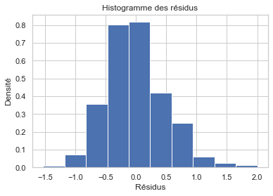

```python
# Histogramme des résidus
plt.hist(train_reg_multi['residus'], density=True)
plt.xlabel('Résidus')
plt.ylabel('Densité')
plt.title('Histogramme des résidus')
plt.show()
```

```python
print("Shapiro_test:", shapiro(train_reg_multi['residus']))
```

```
Shapiro_test: ShapiroResult(statistic=0.9835090637207031, pvalue=2.9546801116886456e-10)
```

À nouveau le test de Shapiro nous indique que la distribution des valeurs n'est pas normale mais l'allure de l'histogramme et le nombre important d'individus (> 30) nous permettent de considérer la normalité des résidus.

#### On vérifie la colinéarité des variables

```python
variables = reg_multi.model.exog
[variance_inflation_factor(variables, i) for i in np.arange(1,variables.shape[1])]
```

```
[1.1426444705801895,
 1.2175852915775147,
 1.4346739578578738,
 1.5822548176073552]
```

Tous les coefficients sont inférieurs à 10, il n'y a pas de problème de colinéarité.

#### On teste l'homoscédasticité

```python
_, pval, __, f_pval = sms.het_breuschpagan(reg_multi.resid, variables)
print('p value test Breusch Pagan:', pval)
```

```
p value test Breusch Pagan: 5.847505967987932e-14
```

P value < 0.05 on rejette H0, la variance des résidus n'est pas constante. À nouveau, en raison du grand de la taille de notre échantillon (> 30) on considère l'homoscédasticité.

On s'intéresse maintenant aux données atypiques et influentes, pour ce faire, on analyse les leviers, les résidus et la distance de Cook.

#### Calcul des leviers

```python
n = train.shape[0]
p = 5

analyses = pd.DataFrame({'obs':np.arange(1, n+1)})

analyses['levier'] = reg_multi.get_influence().hat_matrix_diag

seuil_levier = 2*p/n # seuil au dessus duquel l'observation est considérée comme atypique
analyses.head()
```

|  | obs | levier |
| --- | --- | --- |
| 0 | 1 | 0.006660 |
| 1 | 2 | 0.002396 |
| 2 | 3 | 0.004797 |
| 3 | 4 | 0.004148 |
| 4 | 5 | 0.005805 |

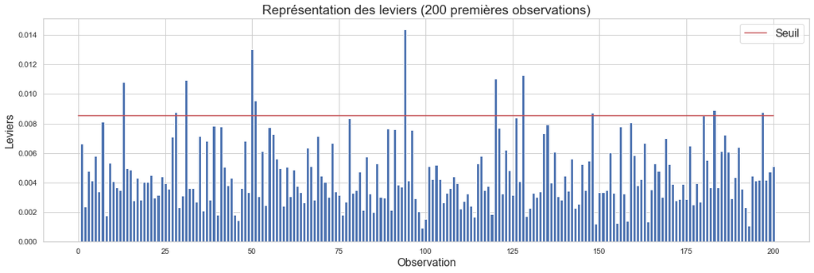

```python
# Représentation des leviers avec un diagramme barre
plt.figure(figsize=(20,6))

plt.bar(analyses['obs'][:200], analyses['levier'][:200])
plt.xlabel('Observation', fontsize=16)
plt.ylabel('Leviers', fontsize=16)

# Ajout de la ligne de seuil
plt.plot([0, 200], [seuil_levier, seuil_levier], color='r', label="Seuil")

plt.legend(prop={'size': 16})
plt.title("Représentation des leviers (200 premières observations)", fontsize=19)
plt.show()
```

```python
# On affiche les points qui dépasse le seuil
leviers = analyses.loc[analyses['levier'] > seuil_levier, :]
print(f"{leviers.shape[0]} points ont des leviers qui dépassent le seuil")
```

```
60 points ont des leviers qui dépassent le seuil
```

#### Calcule des résidus studentisés

```python
analyses['rstudent'] = reg_multi.get_influence().resid_studentized_internal

alpha=0.05
seuil_rstudent = t.ppf(1-alpha/2,n-p-1) # observation atypique si la valeur absolue du résidu est supèrieur au seuil
```

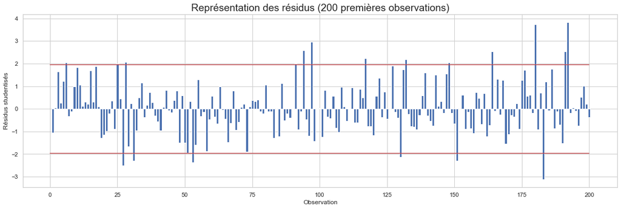

```python
# Représentation des résidus avec un diagramme barre
plt.figure(figsize=(20,6))
plt.bar(analyses['obs'][:200], analyses['rstudent'][:200])
plt.xlabel('Observation')
plt.ylabel('Résidus studentisés')
plt.plot([0, 200], [seuil_rstudent, seuil_rstudent], color='r')
plt.plot([0, 200], [-seuil_rstudent, -seuil_rstudent], color='r')
plt.title("Représentation des résidus (200 premières observations)", fontsize=19)
plt.show()
```

```python
# On affiche les résidus qui dépassent le seuils
residus = analyses.loc[(analyses['rstudent'] > seuil_rstudent) | (analyses['rstudent'] < -seuil_rstudent), :]
print(f"{residus.shape[0]} points ont des résidus qui dépassent le seuil")
```

```
59 points ont des résidus qui dépassent le seuil
```

#### Distance de Cook

```python
influence = reg_multi.get_influence().summary_frame()

influence = influence.sort_index()

influence['cooks_d'] = influence['cooks_d'].array
analyses['dcooks'] = influence['cooks_d'].values

seuil_dcook = 4/(n-p) # seuil au dessus duquel l'observation est considirée comme influente
```

```python
analyses.head()
```

|  | obs | levier | rstudent | dcooks |
| --- | --- | --- | --- | --- |
| 0 | 1 | 0.006660 | -1.042213 | 0.000811 |
| 1 | 2 | 0.002396 | 0.052699 | 0.000492 |
| 2 | 3 | 0.004797 | 1.638291 | 0.000231 |
| 3 | 4 | 0.004148 | 0.268800 | 0.000348 |
| 4 | 5 | 0.005805 | 1.231504 | 0.001353 |

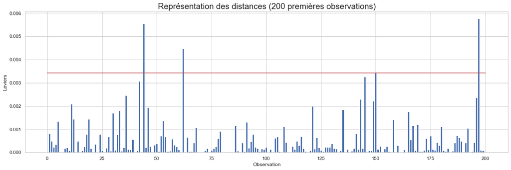

```python
# Représentation des distances de Cook avec un diagramme barre
plt.figure(figsize=(20,6))
plt.bar(analyses['obs'][:200], analyses['dcooks'][:200])
#plt.xticks(np.arange(0, 115, step=5))
plt.xlabel('Observation')
plt.ylabel('Leviers')
plt.plot([0, 200], [seuil_dcook, seuil_dcook], color='r')
plt.title("Représentation des distances (200 premières observations)", fontsize=19)
plt.show()
```

```python
# On affiche les distances qui dépassent le seuil
cook = analyses.loc[analyses['dcooks'] > seuil_dcook, :]
print(f"{residus.shape[0]} points ont des distances de Cook qui dépassent le seuil")
```

```
59 points ont des distances de Cook qui dépassent le seuil
```

```python
# On affiche les points qui dépassent les seuils de levier, résidus et distance de Cooks
analyses.loc[(analyses["obs"].isin(leviers["obs"]))&(analyses["obs"].isin(residus["obs"]))&(analyses["obs"].isin(cook["obs"]))]
```

|  | obs | levier | rstudent | dcooks |
| --- | --- | --- | --- | --- |

**Il n'y a pas d'observation qui soit à la fois atypique et influente.**

À partir du test set, on prédit margin_low à l'aide de notre modèle et on compare avec les margin_low observées.

```python
# On prédit les margin_low à partir des données test
X = test.drop(columns=["is_genuine", "margin_low"])
test_reg_multi = test.copy()
# On ajoute une colonne avec les valeurs prédites à partir des données X
test_reg_multi['margin_low_pred'] = reg_multi.predict(X)
test_reg_multi.head()
```

|  | is_genuine | diagonal | height_left | height_right | margin_low | margin_up | length | margin_low_pred |
| --- | --- | --- | --- | --- | --- | --- | --- | --- |
| 1208 | False | 171.96 | 104.38 | 103.82 | 5.19 | 3.32 | 111.68 | 4.957949 |
| 178 | True | 171.79 | 104.57 | 104.04 | 4.26 | 3.15 | 113.46 | 4.279177 |
| 281 | True | 171.99 | 103.90 | 104.21 | 4.18 | 3.07 | 113.01 | 4.379647 |
| 561 | True | 172.25 | 103.71 | 103.97 | 3.93 | 3.00 | 113.38 | 4.119429 |
| 891 | True | 172.16 | 103.63 | 103.59 | 4.25 | 3.38 | 113.58 | 4.039712 |

```python
# Calcul de la RMSE
y_actual = test_reg_multi["margin_low"]
y_predicted = test_reg_multi["margin_low_pred"]

MSE = mean_squared_error(y_actual, y_predicted)

RMSE_reg_multi = math.sqrt(MSE)
print("\033[1mRoot Mean Square Error:\033[0m", round(RMSE_reg_multi, 3))
```

```
Root Mean Square Error: 0.441
```

## KNeighborsRegressor

Nous utilisons ici le principe des k plus proches voisins.

La valeur de margin_low d'un nouveau point sera calculée à partir de la moyenne des valeurs de margin_low des k voisins les plus proches issus du train set.  
Il nous faut donc déterminer le nombre de k voisins adéquat.

```python
xtrain = train.drop(columns=["is_genuine", "margin_low"])
ytrain = train["margin_low"]

xtest = test.drop(columns=["is_genuine", "margin_low"])
ytest = test["margin_low"]
```

### Détermination du nombre de k voisins adéquat

On cherche à déterminer le nombre de k voisins qui donne le coefficient de détermination le plus élevé.

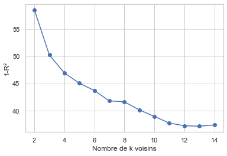

```python
errors = []
for k in range(2,15):
    knn = KNeighborsRegressor(k)
    errors.append(100*(1 - knn.fit(xtrain, ytrain).score(xtest, ytest)))
plt.plot(range(2,15), errors, 'o-')
plt.xlabel("Nombre de k voisins")
plt.ylabel("1-R²")
plt.show()
```

Le point le plus bas de la courbe à le (1-R²) le plus faible, donc le R² le plus élevé, il correspond à k=12.  
On relance l'algorithme du knn avec cette valeur de k.

```python
# On instancie et on entraine l'algorithme
knn = KNeighborsRegressor(12)
knn.fit(xtrain, ytrain)
```

```
KNeighborsRegressor(n_neighbors=12)
```

```python
# On prédit les margin_low à partir des données test
X = test.drop(columns=["is_genuine", "margin_low"])
test_knn = test.copy()

# On ajoute une colonne avec les valeurs prédites à partir des données X
test_knn['margin_low_pred'] = knn.predict(X)
test_knn.head()
```

|  | is_genuine | diagonal | height_left | height_right | margin_low | margin_up | length | margin_low_pred |
| --- | --- | --- | --- | --- | --- | --- | --- | --- |
| 1208 | False | 171.96 | 104.38 | 103.82 | 5.19 | 3.32 | 111.68 | 5.116667 |
| 178 | True | 171.79 | 104.57 | 104.04 | 4.26 | 3.15 | 113.46 | 4.100000 |
| 281 | True | 171.99 | 103.90 | 104.21 | 4.18 | 3.07 | 113.01 | 4.160000 |
| 561 | True | 172.25 | 103.71 | 103.97 | 3.93 | 3.00 | 113.38 | 4.183333 |
| 891 | True | 172.16 | 103.63 | 103.59 | 4.25 | 3.38 | 113.58 | 3.956667 |

```python
# Calcul de la RMSE
y_actual = test_knn["margin_low"]
y_predicted = test_knn["margin_low_pred"]

MSE = mean_squared_error(y_actual, y_predicted)

RMSE_knn = math.sqrt(MSE)
#print("Root Mean Square Error:", round(RMSE_knn, 2))
print("\033[1mRoot Mean Square Error:\033[0m", round(RMSE_knn, 3))
```

```
Root Mean Square Error: 0.396
```

### Comparaison des RMSE

```python
df = pd.DataFrame(np.array([[round(RMSE_mean, 2)], [round(RMSE_reg_simp, 2)], [round(RMSE_reg_multi, 2)], [round(RMSE_knn, 2)]]),
                   columns=["RMSE"], index=[["Imputation mean", "reg_lin_simp", "reg_lin_multi", "knn"]])
print("\033[1mTableau récapitulatif\033[0m")
df.sort_values(by="RMSE")
```

```
Tableau récapitulatif
```

|  | RMSE |
| --- | --- |
| knn | 0.40 |
| reg_lin_multi | 0.44 |
| reg_lin_simp | 0.45 |
| Imputation mean | 0.65 |

La méthode d'implémentation à l'aide du **knn nous donne les meilleurs résultats (RMSE = 0.40)**, nous choisissons de traiter les valeurs manquantes à partir de ce modèle.

```python
# On copie le dataframe d'origine contenant les valeurs manquantes
df_knn = billets.copy()

# On stocke les données explicatives
X = df_knn.drop(columns=["is_genuine", "margin_low"])

# On replace les valeurs manquantes par les valeurs de margin_low prédite à partir du modèle knn
df_knn["margin_low"] = df_knn["margin_low"].fillna(pd.Series(knn.predict(X)))

# On s'assure que toutes les valeurs manquantes ont été comblées
df_knn.isna().sum()
```

```
is_genuine      0
diagonal        0
height_left     0
height_right    0
margin_low      0
margin_up       0
length          0
dtype: int64
```

```python
# On vérifie l'implémentation
df_na = billets.loc[billets["margin_low"].isna()]
liste = df_na.index
df_knn_na = df_knn.loc[df_knn.index.isin(liste)]
df_knn_na.head()
```

|  | is_genuine | diagonal | height_left | height_right | margin_low | margin_up | length |
| --- | --- | --- | --- | --- | --- | --- | --- |
| 72 | True | 171.94 | 103.89 | 103.45 | 4.065833 | 3.25 | 112.79 |
| 99 | True | 171.93 | 104.07 | 104.18 | 4.390833 | 3.14 | 113.08 |
| 151 | True | 172.07 | 103.80 | 104.38 | 4.106667 | 3.02 | 112.93 |
| 197 | True | 171.45 | 103.66 | 103.80 | 4.021667 | 3.62 | 113.27 |
| 241 | True | 171.83 | 104.14 | 104.06 | 4.883333 | 3.02 | 112.36 |

# Modélisation

## Préparation des données

On utilise le dataframe df_knn dans lequel les valeurs manquantes ont été traités grace à KNeighborsRegressor.

La colonne "is_genuine" du jeu de données nous indique la nature du billet (True ou False). Pour plus de clarté, nous décidons de convertir les True en 1 et False en 0 le temps de l'analyse. Ainsi, un vrai billet sera désigné par la valeur 1 et un faux par la valeur 0.

```python
df_knn.head(5)
```

|  | is_genuine | diagonal | height_left | height_right | margin_low | margin_up | length |
| --- | --- | --- | --- | --- | --- | --- | --- |
| 0 | True | 171.81 | 104.86 | 104.95 | 4.52 | 2.89 | 112.83 |
| 1 | True | 171.46 | 103.36 | 103.66 | 3.77 | 2.99 | 113.09 |
| 2 | True | 172.69 | 104.48 | 103.50 | 4.40 | 2.94 | 113.16 |
| 3 | True | 171.36 | 103.91 | 103.94 | 3.62 | 3.01 | 113.51 |
| 4 | True | 171.73 | 104.28 | 103.46 | 4.04 | 3.48 | 112.54 |

```python
# On converti True et False en 1 et 0
df_knn['is_genuine'] = df_knn['is_genuine'].apply(lambda x: 1 if x == True else 0)
```

```python
df_knn.head(5)
```

|  | is_genuine | diagonal | height_left | height_right | margin_low | margin_up | length |
| --- | --- | --- | --- | --- | --- | --- | --- |
| 0 | 1 | 171.81 | 104.86 | 104.95 | 4.52 | 2.89 | 112.83 |
| 1 | 1 | 171.46 | 103.36 | 103.66 | 3.77 | 2.99 | 113.09 |
| 2 | 1 | 172.69 | 104.48 | 103.50 | 4.40 | 2.94 | 113.16 |
| 3 | 1 | 171.36 | 103.91 | 103.94 | 3.62 | 3.01 | 113.51 |
| 4 | 1 | 171.73 | 104.28 | 103.46 | 4.04 | 3.48 | 112.54 |

Les valeurs de la colonne "is_genuine" ont été converties.

Nous allons ensuite découper notre jeu de données en un train set (80% du total) avec lequel chaque modèle sera entrainé et un test set (20% du total) sur lequel on testera nos modèles. On calculera des critères de performance pour nous permettre de comparer ces modèles entre eux et choisir le mieux adapté à notre objectif.

```python
# On découpe notre dataframe en une partie d'entrainement et une de test
train, test = train_test_split(df_knn, test_size=0.2, random_state=42)

print(f"""Le train set est composé de {train.shape[0]} lignes et {train.shape[1]} colonnes.
Le test set est composé de {test.shape[0]} lignes et {test.shape[1]} colonnes.""")
```

```
Le train set est composé de 1200 lignes et 7 colonnes.
Le test set est composé de 300 lignes et 7 colonnes.
```

## Régression logistique

On cherche à expliquer la variable binaire "is_genuine" en fonction des différentes variables quantitatives.

```python
reg_log1 = smf.glm('is_genuine ~ diagonal+height_left+height_right+margin_low+margin_up+length', data=train, family=sm.families.Binomial()).fit()

print(reg_log1.summary())
```

```
                 Generalized Linear Model Regression Results
==============================================================================
Dep. Variable:             is_genuine   No. Observations:                 1200
Model:                            GLM   Df Residuals:                     1193
Model Family:                Binomial   Df Model:                            6
Link Function:                  logit   Scale:                          1.0000
Method:                          IRLS   Log-Likelihood:                -37.337
Date:                Wed, 15 Mar 2023   Deviance:                       74.675
Time:                        15:56:17   Pearson chi2:                 1.67e+03
No. Iterations:                    10
Covariance Type:            nonrobust
================================================================================
                   coef    std err          z      P>|z|      [0.025      0.975]
--------------------------------------------------------------------------------
Intercept      -91.4416    253.349     -0.361      0.718    -587.996     405.112
diagonal        -0.3735      1.134     -0.329      0.742      -2.597       1.850
height_left     -1.7619      1.262     -1.396      0.163      -4.236       0.712
height_right    -2.1830      1.087     -2.009      0.045      -4.313      -0.053
margin_low      -5.1063      0.910     -5.611      0.000      -6.890      -3.323
margin_up       -8.7604      2.083     -4.206      0.000     -12.843      -4.678
length           5.4894      0.863      6.360      0.000       3.798       7.181
================================================================================
```

On retire les variables qui ne sont pas significatives (p-value > 0.05), on commence par retirer la variable "diagonal".

```python
reg_log1 = smf.glm('is_genuine ~ height_left+height_right+margin_low+margin_up+length', data=train, family=sm.families.Binomial()).fit()

print(reg_log1.summary())
```

```
                 Generalized Linear Model Regression Results
==============================================================================
Dep. Variable:             is_genuine   No. Observations:                 1200
Model:                            GLM   Df Residuals:                     1194
Model Family:                Binomial   Df Model:                            5
Link Function:                  logit   Scale:                          1.0000
Method:                          IRLS   Log-Likelihood:                -37.392
Date:                Wed, 15 Mar 2023   Deviance:                       74.783
Time:                        15:56:17   Pearson chi2:                 1.62e+03
No. Iterations:                    10
Covariance Type:            nonrobust
================================================================================
                   coef    std err          z      P>|z|      [0.025      0.975]
--------------------------------------------------------------------------------
Intercept     -152.3159    173.838     -0.876      0.381    -493.033     188.401
height_left     -1.7720      1.260     -1.406      0.160      -4.242       0.698
height_right    -2.1534      1.088     -1.979      0.048      -4.286      -0.021
margin_low      -5.0081      0.843     -5.941      0.000      -6.660      -3.356
margin_up       -8.7277      2.084     -4.188      0.000     -12.812      -4.643
length           5.4368      0.837      6.494      0.000       3.796       7.078
================================================================================
```

On retire ensuite la variable 'height_left'.

```python
reg_log1 = smf.glm('is_genuine ~ height_right+margin_low+margin_up+length', data=train, family=sm.families.Binomial()).fit()

print(reg_log1.summary())
```

```
                 Generalized Linear Model Regression Results
==============================================================================
Dep. Variable:             is_genuine   No. Observations:                 1200
Model:                            GLM   Df Residuals:                     1195
Model Family:                Binomial   Df Model:                            4
Link Function:                  logit   Scale:                          1.0000
Method:                          IRLS   Log-Likelihood:                -38.395
Date:                Wed, 15 Mar 2023   Deviance:                       76.790
Time:                        15:56:17   Pearson chi2:                 2.04e+03
No. Iterations:                    10
Covariance Type:            nonrobust
================================================================================
                   coef    std err          z      P>|z|      [0.025      0.975]
--------------------------------------------------------------------------------
Intercept     -292.8525    150.583     -1.945      0.052    -587.990       2.285
height_right    -2.6690      1.114     -2.396      0.017      -4.852      -0.486
margin_low      -5.0618      0.814     -6.215      0.000      -6.658      -3.466
margin_up       -8.6671      2.034     -4.262      0.000     -12.653      -4.681
length           5.5242      0.832      6.641      0.000       3.894       7.155
================================================================================
```

On teste ensuite notre modèle sur le test set, on obtiendra des valeurs de "is_genuine" prédites que l'on pourra comparer aux valeurs de "is_genuine" observées.

```python
# On prépare les données explicatives en retirant la variable à expliquée "is_genuine" et les variables non significatives
X = test.drop(columns=["is_genuine", "diagonal", "height_left"])
test_reg_log = test.copy()

# On prédit les valeurs de "is_genuine"
test_reg_log['is_genuine_proba'] = reg_log1.predict(X)
test_reg_log.head()
```

|  | is_genuine | diagonal | height_left | height_right | margin_low | margin_up | length | is_genuine_proba |
| --- | --- | --- | --- | --- | --- | --- | --- | --- |
| 1116 | 0 | 172.26 | 103.90 | 104.12 | 4.9900 | 3.42 | 111.27 | 0.000017 |
| 1368 | 0 | 171.65 | 104.32 | 104.38 | 5.6500 | 3.24 | 112.30 | 0.000429 |
| 422 | 1 | 171.53 | 103.53 | 103.63 | 4.0400 | 2.96 | 112.76 | 0.999367 |
| 413 | 1 | 172.30 | 103.66 | 103.50 | 4.1325 | 3.16 | 112.95 | 0.998586 |
| 451 | 1 | 172.17 | 103.79 | 103.54 | 4.0700 | 2.78 | 113.03 | 0.999973 |

La viariable "is_genuine_proba" contient la probabilité que le billet soit vrai.  
On fixe un seuil de 0.5, si la probabilité est supérieure ou égale à ce seuil, le billet est vrai (1), sinon le billet est faux (0)

```python
# On fixe le seuil
seuil = 0.5

# On crée une colonne "is_genuine_pred" avec les valeurs 0 et 1 en fonction de la probabilité d'obtenir 1
test_reg_log["is_genuine_pred"] = np.where(test_reg_log["is_genuine_proba"] >= seuil, 1, 0)
test_reg_log.head()
```

|  | is_genuine | diagonal | height_left | height_right | margin_low | margin_up | length | is_genuine_proba | is_genuine_pred |
| --- | --- | --- | --- | --- | --- | --- | --- | --- | --- |
| 1116 | 0 | 172.26 | 103.90 | 104.12 | 4.9900 | 3.42 | 111.27 | 0.000017 | 0 |
| 1368 | 0 | 171.65 | 104.32 | 104.38 | 5.6500 | 3.24 | 112.30 | 0.000429 | 0 |
| 422 | 1 | 171.53 | 103.53 | 103.63 | 4.0400 | 2.96 | 112.76 | 0.999367 | 1 |
| 413 | 1 | 172.30 | 103.66 | 103.50 | 4.1325 | 3.16 | 112.95 | 0.998586 | 1 |
| 451 | 1 | 172.17 | 103.79 | 103.54 | 4.0700 | 2.78 | 113.03 | 0.999973 | 1 |

```python
# On affiche les prédictions qui ne correspondent pas aux observations
test_reg_log.loc[test_reg_log["is_genuine"] != test_reg_log["is_genuine_pred"]]
```

|  | is_genuine | diagonal | height_left | height_right | margin_low | margin_up | length | is_genuine_proba | is_genuine_pred |
| --- | --- | --- | --- | --- | --- | --- | --- | --- | --- |
| 1190 | 0 | 171.45 | 104.21 | 104.18 | 4.55 | 3.52 | 113.21 | 0.720647 | 1 |
| 1281 | 0 | 171.62 | 104.53 | 103.64 | 4.89 | 3.16 | 112.54 | 0.521701 | 1 |
| 1073 | 0 | 172.13 | 103.67 | 103.82 | 4.27 | 3.22 | 112.15 | 0.517568 | 1 |
| 1325 | 0 | 171.83 | 104.39 | 104.17 | 5.51 | 3.33 | 113.64 | 0.534243 | 1 |

Maintenant que les prédictions ont été réalisées, on analyse la qualité de notre modèle en affichant la matrice de confusion et en calculant les critères de performances.

```python
# On affiche la matrice de confusion

matrice = confusion_matrix(test_reg_log["is_genuine"], test_reg_log["is_genuine_pred"])

classes = [0, 1]
mf = pd.DataFrame(matrice, columns=['prédit ' + str(i) for i in classes])
mf.index = ['observé ' + str(i) for i in classes]

print("""\033[1mMatrice de confusion\033[0m \n
1 : le billet est vrai
0 : le billet est faux""")
mf
```

```
Matrice de confusion

1 : le billet est vrai
0 : le billet est faux
```

|  | prédit 0 | prédit 1 |
| --- | --- | --- |
| observé 0 | 106 | 4 |
| observé 1 | 0 | 190 |

**Vrai positif (TP):** prédit 1, observé 1  
**Vrai négatif (TN):** prédit 0, observé 0  
**Faux positif (FP):** prédit 1, observé 0  
**Faux négatif (FN):** prédit 0, observé 1

La matrice de confusion nous indique que nous avons 4 faux positifs. Cela signifie que 4 billets détectés comme étant vrais, sont en réalité de faux billets, c'est la situation que l'on veut éviter le plus.

### Critères de performance

Les différents critères sont calculés à partir des expressions suivantes:

accuracy : (VP + VN) / (VP + VN + FP + FN)  
rappel : TP / (TP + FN)  
précision : TP / (TP + FP)  
spécificité : TN / (FP + TN)  
F-mesure : 2*((précision* Rappel) / (précision + Rappel))

```python
accuracy_reg = round((accuracy_score(test_reg_log["is_genuine"], test_reg_log["is_genuine_pred"])*100), 1)
rappel_reg = round((recall_score(test_reg_log["is_genuine"], test_reg_log["is_genuine_pred"])*100), 1)
precision_reg = round((precision_score(test_reg_log["is_genuine"], test_reg_log["is_genuine_pred"])*100), 1)
specificity = round((matrice[0,0]/(matrice[0,1]+matrice[0,0])*100), 1)
f_mesure_reg = round((f1_score(test_reg_log["is_genuine"], test_reg_log["is_genuine_pred"])*100), 1)

print(f"Critères de performance \naccuracy : {accuracy_reg} % \nrappel : {rappel_reg} % \nprécision : {precision_reg} % \nspécificité : {specificity} % \nF-mesure : {f_mesure_reg} %")
```

```
Critères de performance
accuracy : 98.7 %
rappel : 100.0 %
précision : 97.9 %
spécificité : 96.4 %
F-mesure : 99.0 %
```

accuracy : notre modèle donne 98.7 % de bonnes prédictions  
rappel : notre modèle permet de détecter 100 % des vrais billets.  
précision : 97.9% des billets détectés comme vrai par le modèle sont en effet de vrais billets  
spécificité : 96.4% des faux billets ont été détecté par le modèle

### Courbe ROC

Cette courbe s'obtient en représentant la sensibilité (taux de vrai positif) en fonction de la spécificité (taux de faux positif) pour différentes valeurs de seuil. Le calcul de l'aire sous la courbe nous permet de déterminer la performance de notre modèle.

```python
# Calcul de l'aire sous la courbe
log_roc_auc = roc_auc_score(test_reg_log["is_genuine"], test_reg_log["is_genuine_pred"])

# On récupère le taux de faux et de vrais positifs ainsi que les valeurs de seuil pour tracer la courbe
fpr, tpr, treshold = roc_curve(test_reg_log["is_genuine"], test_reg_log["is_genuine_proba"])
```

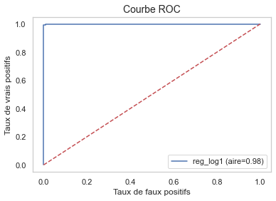

```python
# Réprésentation graphique de la courbe ROC
plt.figure()

plt.plot(fpr, tpr, label="reg_log1 (aire=%0.2f)" % log_roc_auc) # Courbe ROC
plt.plot([0, 1], [0,1], "r--") # Première bisextrice

plt.xlabel("Taux de faux positifs")
plt.ylabel("Taux de vrais positifs")
plt.title("Courbe ROC", fontsize=14)
plt.legend()
plt.grid(False)
plt.show()
```

L'aire sous la courbe ROC est de 0.98, notre modèle est donc très performant.

## K-means

Pour cette méthode on commence par placer aléatoirement un nombre de centroïdes (centre de gravité) égal au nombre de clusters souhaités, parmi nos points. Ensuite on regroupe les points les plus proches de chaque centroïde, on calcule la position du nouveau centre de gravité et on déplace le centroïde sur la nouvelle position. On répète ce processus de manière itérative jusqu'à convergence de l'algorithme.

Pour déterminer le nombre de clusters adéquats on fait fonctionner l'algorithme pour différents nombres de clusters et on choisit celui avec le meilleur coefficient de silhouette.

```python
X = train.drop(columns="is_genuine")
```

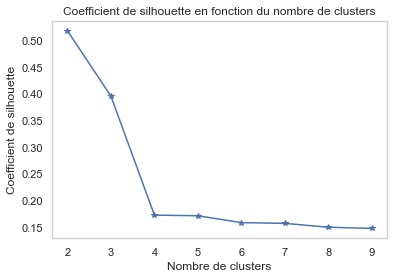

```python
# On crée une liste vide
silhouette = []

# Pour chaque tour de boucle on lance l'algorithme du kmeans pour un nombre de clusters donnée et on calcul le silhouette score
# Puis on stocke la valeur dans la liste sihlouette
for i in range(2, 10):
    cls = cluster.KMeans(n_clusters= i, n_init=10, init='random', random_state= 10).fit(X)

    silh = metrics.silhouette_score(X, cls.labels_)
    silhouette.append(silh)

# On affiche le silhouette score pour chaque nombre de cluster
plt.plot(range(2, 10), silhouette, marker="*")
plt.xlabel("Nombre de clusters")
plt.ylabel("Coefficient de silhouette")
plt.title("Coefficient de silhouette en fonction du nombre de clusters")
plt.grid(False)
plt.show()
```

Le silhouette score est le plus élevé pour un nombre de deux clusters, on choisit cette partition.

```python
# On instancie l'algorithme pour 2 clusters
cls = cluster.KMeans(n_clusters=2, n_init=10, init='random', random_state= 10)

# On fit
cls.fit(X)
```

```
KMeans(init='random', n_clusters=2, n_init=10, random_state=10)
```

```python
# On ajoute la colonne "cluster" avec le numéro de cluster pour chaque individus
df_kmeans = train.copy()
df_kmeans["cluster"] = cls.labels_
df_kmeans.head()
```

|  | is_genuine | diagonal | height_left | height_right | margin_low | margin_up | length | cluster |
| --- | --- | --- | --- | --- | --- | --- | --- | --- |
| 382 | 1 | 172.28 | 104.62 | 103.80 | 4.08 | 3.08 | 113.26 | 0 |
| 538 | 1 | 171.90 | 104.50 | 103.49 | 4.08 | 2.82 | 113.50 | 0 |
| 1493 | 0 | 171.63 | 104.33 | 104.61 | 4.88 | 3.35 | 112.16 | 1 |
| 1112 | 0 | 172.06 | 104.28 | 104.31 | 5.61 | 3.27 | 111.61 | 1 |
| 324 | 1 | 172.10 | 104.42 | 103.60 | 4.18 | 2.89 | 113.32 | 0 |

### Projection des individus avec clusters

On réalise une ACP avant de projeter les points sur le premier plan factoriel.

```python
df_acp = df_kmeans.drop(columns=["is_genuine", "cluster"])
```

```python
# On choisit le maximum de variables synthétiques possibles pour commencer
n_components = 6

# On instancie
pca = PCA(n_components= n_components)

# On entraine
pca.fit(df_acp)

# On affiche la variance expliquée par chaque composante
print(pca.explained_variance_ratio_)
```

```
[0.69472452 0.11474648 0.06358568 0.05637769 0.04674578 0.02381985]
```

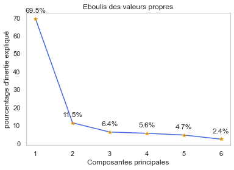

```python
# On enregistre les valeurs de variance expliquée par chaque composante
scree = (pca.explained_variance_ratio_*100).round(2)

# On stocke la liste de nos composantes qui sera l'abscisse de notre graphique
x_list = range(1, n_components+1)
list(x_list)

# Représentation du pourcentage d'inertie expliqué pour chaques composantes
plt.plot(x_list, scree,c="royalblue",marker='*', markeredgecolor= "orange")
plt.xlabel("Composantes principales")
plt.ylabel("pourcentage d'inertie expliqué")
plt.title("Eboulis des valeurs propres")

# Affichage des pourcentages sur le graph
for x,y in zip(x_list,scree):

    label = "{:.1f}%".format(y)

    plt.annotate(label,
                 (x,y),
                 textcoords="offset points", # position du texte
                 xytext=(0,10), # distance du texte au points (x,y)
                 ha='center')

plt.grid(False)
plt.show(block=False)
```

Méthode du coude, on choisit 2 composantes principales.

```python
pca = PCA(n_components= 2)
pca.fit(df_acp)

# projeter X_scaled sur les composantes principales
X_proj = pca.transform(df_acp)

# On ajoute au dataframe X_proj une colonne avec les clusters du Kmeans
X_proj_kmeans = pd.DataFrame(X_proj, columns=["F1", "F2"], index=train.drop(columns="is_genuine").index)
X_proj_kmeans["cluster"] = cls.labels_
X_proj_kmeans["ig_genuine"] = df_kmeans["is_genuine"].values
```

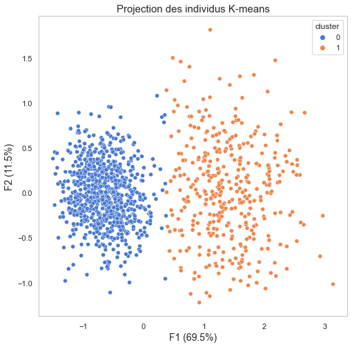

```python
# On représente nos individus sur le premier plan factoriel
plt.figure(figsize=(8, 8))

# nom des axes, avec le pourcentage d'inertie expliqué
plt.xlabel('F{} ({}%)'.format(1, round(100*pca.explained_variance_ratio_[0],1)), fontsize= 14)
plt.ylabel('F{} ({}%)'.format(2, round(100*pca.explained_variance_ratio_[1],1)), fontsize= 14)

sns.scatterplot(data= X_proj_kmeans, x="F1", y="F2", hue="cluster", palette="muted") # Nuage des individus

plt.title("Projection des individus K-means", fontsize=15)
plt.grid(False)
plt.show()
```

Le regroupement effectué par l'algorithme est cohérent, il n'y a pas de superposition des clusters. On voit que l'algorithme a attribué le label 0 aux points situés à gauche et 1 à ceux de droite. En réalité, et d'après l'ACP réalisée en début d'analyse, les points situés à gauche représentent les vrais billets et les points à droite les faux billets. Les résultats seront donc inversés lors des prédictions car le k-means attribut le chiffre 0 au groupe des vrais billets (1) et 1 au groupe des faux billets (0).  
Cela sera prix en compte lors de l'affichage des prédictions.

On prédit "is_genuine" sur le test set et on compare avec les "is_genuine" observées.  
Ici on utilise predict() qui indique le cluster auquel appartient l'individu à partir de la position des centroïdes.

```python
# On copie le test set
test_kmeans = test.copy()

# On enlève la variable à expliquée
X_test = test.drop(columns=["is_genuine"])
```

```python
# On ajoute une colonne à test_kmeans avec les prédictions de cluster pour chaque individus
test_kmeans["is_genuine_pred"] = cls.predict(X_test)# predict indique dequel cluster notre individus est le plus proche

# On inverse le résultat des prédictions car le kmeans numérote les clusters inversement à la nature des billets
test_kmeans["is_genuine_pred"] = test_kmeans["is_genuine_pred"].apply(lambda x: 0 if x == 1 else 1)
test_kmeans.head()
```

|  | is_genuine | diagonal | height_left | height_right | margin_low | margin_up | length | is_genuine_pred |
| --- | --- | --- | --- | --- | --- | --- | --- | --- |
| 1116 | 0 | 172.26 | 103.90 | 104.12 | 4.9900 | 3.42 | 111.27 | 0 |
| 1368 | 0 | 171.65 | 104.32 | 104.38 | 5.6500 | 3.24 | 112.30 | 0 |
| 422 | 1 | 171.53 | 103.53 | 103.63 | 4.0400 | 2.96 | 112.76 | 1 |
| 413 | 1 | 172.30 | 103.66 | 103.50 | 4.1325 | 3.16 | 112.95 | 1 |
| 451 | 1 | 172.17 | 103.79 | 103.54 | 4.0700 | 2.78 | 113.03 | 1 |

```python
# On affiche les cas où les prédictions sont différentes des observations
test_kmeans.loc[test_kmeans["is_genuine"] != test_kmeans["is_genuine_pred"]]
```

|  | is_genuine | diagonal | height_left | height_right | margin_low | margin_up | length | is_genuine_pred |
| --- | --- | --- | --- | --- | --- | --- | --- | --- |
| 1190 | 0 | 171.45 | 104.21 | 104.18 | 4.55 | 3.52 | 113.21 | 1 |
| 1452 | 0 | 171.93 | 104.15 | 103.98 | 4.57 | 3.57 | 112.71 | 1 |
| 1281 | 0 | 171.62 | 104.53 | 103.64 | 4.89 | 3.16 | 112.54 | 1 |
| 1073 | 0 | 172.13 | 103.67 | 103.82 | 4.27 | 3.22 | 112.15 | 1 |
| 1325 | 0 | 171.83 | 104.39 | 104.17 | 5.51 | 3.33 | 113.64 | 1 |
| 1341 | 0 | 171.94 | 104.21 | 104.10 | 4.28 | 3.47 | 112.23 | 1 |

```python
# On affiche la matrice de confusion
matrice = confusion_matrix(test_kmeans["is_genuine"], test_kmeans["is_genuine_pred"])

classes = [0, 1]
mf = pd.DataFrame(matrice, columns=['prédit ' + str(i) for i in classes])
mf.index = ['observé ' + str(i) for i in classes]

print("""\033[1mMatrice de confusion\033[0m \n
1 : le billet est vrai
0 : le billet est faux""")
mf
```

```
Matrice de confusion

1 : le billet est vrai
0 : le billet est faux
```

|  | prédit 0 | prédit 1 |
| --- | --- | --- |
| observé 0 | 104 | 6 |
| observé 1 | 0 | 190 |

Il y a 6 faux positifs et 0 faux négatifs.

```python
# Calcul des critères de performances

accuracy_kmeans = round((accuracy_score(test_kmeans["is_genuine"], test_kmeans["is_genuine_pred"])*100), 1)
rappel_kmeans = round((recall_score(test_kmeans["is_genuine"], test_kmeans["is_genuine_pred"])*100), 1)
precision_kmeans = round((precision_score(test_kmeans["is_genuine"], test_kmeans["is_genuine_pred"])*100), 1)
specificity_kmeans = round((matrice[0,0]/(matrice[0,1]+matrice[0,0])*100), 1)
f_mesure_kmeans = round((f1_score(test_kmeans["is_genuine"], test_kmeans["is_genuine_pred"])*100), 1)

print(f"Critères de performance \naccuracy : {accuracy_kmeans} % \nrappel : {rappel_kmeans} % \nprécision : {precision_kmeans} % \nspécificité : {specificity_kmeans} % \nF-mesure : {f_mesure_kmeans} %")
```

```
Critères de performance
accuracy : 98.0 %
rappel : 100.0 %
précision : 96.9 %
spécificité : 94.5 %
F-mesure : 98.4 %
```

accuracy : notre modèle donne 98 % de bonnes prédictions  
rappel : notre modèle permet de détecter 100 % des vrais billets.  
précision : 96.9 % des billets détectés comme vrais par le modèle sont en effet de vrais billets  
spécificité : 94.5 % des faux billets ont été détectés par le modèle

## RandomForestClassifier

Ici nous utilisons l'algorithme RandomForest qui nous permet de créer une forêt aléatoire composée de plusieurs arbres de décision. Nous pourrons ensuite réaliser des prédictions à partir de la moyenne des résultats de nos arbres.

```python
X_train = train.drop(columns="is_genuine")
y_train = train["is_genuine"]
```

### Optimisation des paramètres avec GridsearchCV

On cherche les paramètres qui nous donnent la meilleure spécificité (moins de faux positifs). À noter qu'avec GridSearch il n'y a pas de score prédéfini correspondant à la spécificité, nous créons donc le score qui permettra d'évaluer la performance du modèle à partir du rappel (recall_score). La spécificité étant l'inverse du rappel.

```python
clf_cv = RandomForestClassifier(random_state=42)
specificity_score_2 = make_scorer(recall_score, pos_label=0) # Création du score du spécificité

# Paramètres que l'on veut tester
param_grid = {
    'n_estimators': [200, 500],
    'max_features': ['sqrt', 'log2'],
    'max_depth' : [4,5,6,7,8],
    'criterion' :['gini', 'entropy']
}

cv_randomf = GridSearchCV(estimator=clf_cv,
                          param_grid=param_grid,
                          cv= 5,
                          scoring=specificity_score_2 )

cv_randomf.fit(X_train, y_train)

# On affiche les meilleurs paramètres
print("Meilleurs paramètres:\n", cv_randomf.best_params_)
```

```
Meilleurs paramètres:
 {'criterion': 'gini', 'max_depth': 5, 'max_features': 'sqrt', 'n_estimators': 200}
```

On relance l'algorithme avec les meilleurs paramètres

```python
# On instancie
clf = RandomForestClassifier(n_estimators=200,
                             max_depth= 5,
                             criterion= 'gini',
                             max_features= 'sqrt',
                             random_state=42)

# On entraine
clf.fit(X_train, y_train)
```

```
RandomForestClassifier(max_depth=5, n_estimators=200, random_state=42)
```

On prédit "is_genuine" sur le test set et on compare avec les "is_genuine" observées.

```python
test_forest = test.copy()
X_test = test.drop(columns="is_genuine")

# On prédit les valeurs de "is_genuine"
test_forest["is_genuine_pred"] = clf.predict(X_test)
test_forest["proba_0"] =clf.predict_proba(X_test)[:,0]
test_forest["proba_1"] =clf.predict_proba(X_test)[:,1]
test_forest.head()
```

|  | is_genuine | diagonal | height_left | height_right | margin_low | margin_up | length | is_genuine_pred | proba_0 | proba_1 |
| --- | --- | --- | --- | --- | --- | --- | --- | --- | --- | --- |
| 1116 | 0 | 172.26 | 103.90 | 104.12 | 4.9900 | 3.42 | 111.27 | 0 | 0.996618 | 0.003382 |
| 1368 | 0 | 171.65 | 104.32 | 104.38 | 5.6500 | 3.24 | 112.30 | 0 | 0.993830 | 0.006170 |
| 422 | 1 | 171.53 | 103.53 | 103.63 | 4.0400 | 2.96 | 112.76 | 1 | 0.003004 | 0.996996 |
| 413 | 1 | 172.30 | 103.66 | 103.50 | 4.1325 | 3.16 | 112.95 | 1 | 0.002205 | 0.997795 |
| 451 | 1 | 172.17 | 103.79 | 103.54 | 4.0700 | 2.78 | 113.03 | 1 | 0.000747 | 0.999253 |

```python
# On affiche les cas où les prédictions sont différentes des observations
test_forest.loc[test_forest["is_genuine"] != test_forest["is_genuine_pred"]]
```

|  | is_genuine | diagonal | height_left | height_right | margin_low | margin_up | length | is_genuine_pred | proba_0 | proba_1 |
| --- | --- | --- | --- | --- | --- | --- | --- | --- | --- | --- |
| 1190 | 0 | 171.45 | 104.21 | 104.18 | 4.55 | 3.52 | 113.21 | 1 | 0.223415 | 0.776585 |
| 1452 | 0 | 171.93 | 104.15 | 103.98 | 4.57 | 3.57 | 112.71 | 1 | 0.305554 | 0.694446 |
| 1281 | 0 | 171.62 | 104.53 | 103.64 | 4.89 | 3.16 | 112.54 | 1 | 0.443072 | 0.556928 |

```python
# On affiche la matrice de confusion
matrice = confusion_matrix(test_forest["is_genuine"], test_forest["is_genuine_pred"])

classes = [0, 1]
mf = pd.DataFrame(matrice, columns=['prédit ' + str(i) for i in classes])
mf.index = ['observé ' + str(i) for i in classes]

print("""\033[1mMatrice de confusion\033[0m \n
1 : le billet est vrai
0 : le billet est faux""")
mf
```

```
Matrice de confusion

1 : le billet est vrai
0 : le billet est faux
```

|  | prédit 0 | prédit 1 |
| --- | --- | --- |
| observé 0 | 107 | 3 |
| observé 1 | 0 | 190 |

Ce modèle nous donne 3 faux positifs et 0 faux négatif.

```python
# Calcul des critères de performances

accuracy_forest = round((accuracy_score(test_forest["is_genuine"], test_forest["is_genuine_pred"])*100), 1)
rappel_forest = round((recall_score(test_forest["is_genuine"], test_forest["is_genuine_pred"])*100), 1)
precision_forest = round((precision_score(test_forest["is_genuine"], test_forest["is_genuine_pred"])*100), 1)
specificity_forest = round((matrice[0,0]/(matrice[0,1]+matrice[0,0])*100), 1)
f_mesure_forest = round((f1_score(test_forest["is_genuine"], test_forest["is_genuine_pred"])*100), 1)

print(f"Critères de performance \naccuracy : {accuracy_forest} % \nrappel : {rappel_forest} % \nprécision : {precision_forest} % \nspécificité : {specificity_forest} % \nF-mesure : {f_mesure_forest} %")
```

```
Critères de performance
accuracy : 99.0 %
rappel : 100.0 %
précision : 98.4 %
spécificité : 97.3 %
F-mesure : 99.2 %
```

accuracy : notre modèle donne 99 % de bonnes prédictions  
rappel : notre modèle permet de détecter 100 % des vrais billets.  
précision : 98.4 % des billets détectés comme vrais par le modèle sont en effet de vrais billets  
spécificité : 97.3 % des faux billets ont été détectés par le modèle

## KNeighborsClassifier

Nous utilisons ici l'algorithme KNN pour réaliser une classification. La valeur "is_genuine" d'un nouveau point sera prédite à partir des is_genuine des k voisins les plus proches.

Nous commençons par déterminer le nombre de k voisins qui permet d'obtenir la meilleure spécificité (moins de faux positifs), pour cela on utilise GridSearchCV.

```python
specificity_score = make_scorer(recall_score, pos_label=0) # Création du score du spécificité

# Paramètres que l'on veut tester
param_grid = {'n_neighbors': range(2,16)}

cv_knn = GridSearchCV(
    KNeighborsClassifier(),
    param_grid,
    cv=5,
    scoring=specificity_score)

cv_knn.fit(X_train, y_train)

# On affiche les meilleurs paramètres
print("Meilleurs paramètres:\n", cv_knn.best_params_)
```

```
Meilleurs paramètres:
 {'n_neighbors': 2}
```

```python
# On instancie
knn = KNeighborsClassifier(2)

# On entraine
knn.fit(X_train, y_train)
```

```
KNeighborsClassifier(n_neighbors=2)
```

```python
test_knn = test.copy()
X_test = test.drop(columns="is_genuine")

# On prédit les valeurs de "is_genuine"
test_knn["is_genuine_pred"] = knn.predict(X_test)
test_knn["proba_0"] = knn.predict_proba(X_test)[:,0]
test_knn["proba_1"] = knn.predict_proba(X_test)[:,1]

test_knn.head()
```

|  | is_genuine | diagonal | height_left | height_right | margin_low | margin_up | length | is_genuine_pred | proba_0 | proba_1 |
| --- | --- | --- | --- | --- | --- | --- | --- | --- | --- | --- |
| 1116 | 0 | 172.26 | 103.90 | 104.12 | 4.9900 | 3.42 | 111.27 | 0 | 1.0 | 0.0 |
| 1368 | 0 | 171.65 | 104.32 | 104.38 | 5.6500 | 3.24 | 112.30 | 0 | 1.0 | 0.0 |
| 422 | 1 | 171.53 | 103.53 | 103.63 | 4.0400 | 2.96 | 112.76 | 1 | 0.0 | 1.0 |
| 413 | 1 | 172.30 | 103.66 | 103.50 | 4.1325 | 3.16 | 112.95 | 1 | 0.0 | 1.0 |
| 451 | 1 | 172.17 | 103.79 | 103.54 | 4.0700 | 2.78 | 113.03 | 1 | 0.0 | 1.0 |

```python
# On affiche les cas où les prédictions sont différentes des observations
test_knn.loc[test_knn["is_genuine"] != test_knn["is_genuine_pred"]]
```

|  | is_genuine | diagonal | height_left | height_right | margin_low | margin_up | length | is_genuine_pred | proba_0 | proba_1 |
| --- | --- | --- | --- | --- | --- | --- | --- | --- | --- | --- |
| 1190 | 0 | 171.45 | 104.21 | 104.18 | 4.55 | 3.52 | 113.21 | 1 | 0.0 | 1.0 |
| 1073 | 0 | 172.13 | 103.67 | 103.82 | 4.27 | 3.22 | 112.15 | 1 | 0.0 | 1.0 |
| 755 | 1 | 171.62 | 104.12 | 103.81 | 4.38 | 3.13 | 112.64 | 0 | 0.5 | 0.5 |

```python
# On affiche la matrice de confusion
matrice = confusion_matrix(test_knn["is_genuine"], test_knn["is_genuine_pred"])

classes = [0, 1]
mf = pd.DataFrame(matrice, columns=['prédit ' + str(i) for i in classes])
mf.index = ['observé ' + str(i) for i in classes]

print("""\033[1mMatrice de confusion\033[0m \n
1 : le billet est vrai
0 : le billet est faux""")
mf
```

```
Matrice de confusion

1 : le billet est vrai
0 : le billet est faux
```

|  | prédit 0 | prédit 1 |
| --- | --- | --- |
| observé 0 | 108 | 2 |
| observé 1 | 1 | 189 |

Il y 2 faux positifs et 1 faux négatif.

```python
# Calcul des critères de performances

accuracy_knn = round((accuracy_score(test_knn["is_genuine"], test_knn["is_genuine_pred"])*100), 1)
rappel_knn = round((recall_score(test_knn["is_genuine"], test_knn["is_genuine_pred"])*100), 1)
precision_knn = round((precision_score(test_knn["is_genuine"], test_knn["is_genuine_pred"])*100), 1)
specificity_knn = round((matrice[0,0]/(matrice[0,1]+matrice[0,0])*100), 1)
f_mesure_knn = round((f1_score(test_knn["is_genuine"], test_knn["is_genuine_pred"])*100), 1)

print(f"Critères de performance \naccuracy : {accuracy_knn} % \nrappel : {rappel_knn} % \nprécision : {precision_knn} % \nspécificité : {specificity_knn} % \nF-mesure : {f_mesure_knn} %")
```

```
Critères de performance
accuracy : 99.0 %
rappel : 99.5 %
précision : 99.0 %
spécificité : 98.2 %
F-mesure : 99.2 %
```

accuracy : notre modèle donne 99 % de bonnes prédictions  
rappel : notre modèle permet de détecter 99.5 % des vrais billets.  
précision : 99 % des billets détectés comme vrais par le modèle sont en effet de vrais billets  
spécificité : 98.2 % des faux billets ont été détectés par le modèle

### Comparaison entre les modèles

```python
# Création dataframe récapitulant les critères de performances des deux modèle
recap_criteres = pd.DataFrame(np.array([[accuracy_reg, rappel_reg, precision_reg, specificity, f_mesure_reg],
                                        [accuracy_kmeans, rappel_kmeans, precision_kmeans, specificity_kmeans, f_mesure_kmeans],
                                        [accuracy_forest, rappel_forest, precision_forest, specificity_forest, f_mesure_forest],
                                        [accuracy_knn, rappel_knn, precision_knn, specificity_knn, f_mesure_knn]]),
                    columns=['accuracy', 'rappel', 'précision', 'spécificité', 'F-mesure'],
                    index=["reg_log", "k-means", "random_forest", "knnClassifier"])
print("             \033[1mCritères de performance (en %)\033[0m")
recap_criteres
```

```
             Critères de performance (en %)
```

|  | accuracy | rappel | précision | spécificité | F-mesure |
| --- | --- | --- | --- | --- | --- |
| reg_log | 98.7 | 100.0 | 97.9 | 96.4 | 99.0 |
| k-means | 98.0 | 100.0 | 96.9 | 94.5 | 98.4 |
| random_forest | 99.0 | 100.0 | 98.4 | 97.3 | 99.2 |
| knnClassifier | 99.0 | 99.5 | 99.0 | 98.2 | 99.2 |

#### Observations:

- Les 4 modèles ont globalement de très bonnes performances ( tous les taux > 94 % )
- **RandomForest et knnClassifier** donnent le taux de bonnes prédictions le plus élevé (**accuracy: 99 %**)
- knnclassifier à un rappel de 99.5%, contrairement aux autres modèles il donne un faux négatif.
- Les taux de précision ne sont pas parfaits, **certains billets prédits vrais sont en réalité faux !**
- **knnClassifier** a la **meilleure spécificité**, il détecte mieux les faux billets, il donne **moins de faux positifs**.

Dans notre contexte, nous voulons un **modèle qui limite le nombre de faux positifs**. En effet, une telle situation est à éviter car elle correspond à la détection d'un vrai billet quand celui-ci est en réalité un faux. Le modèle retenu doit donc avoir une très bonne spécificité. L'algorithme **knnClassifier répond le mieux à notre problématique**, en plus de ses très bons taux pour les autres critères il a la meilleure spécificité (le moins de faux positif), c'est ce modèle qui est retenu.

## Exportation des données

On sauvegarde dans un fichier csv les données qui ont servi à l'entrainement et au test de nos modèles.  
L'entièreté de ce jeu de données sera cette fois-ci utilisée pour entrainer le modèle qui a été retenu.

```python
df_knn.to_csv("Data/df_knn.csv", index=False)
```

## Conclusion

- D'après l'analyse du jeu de données, la variable length à une influence importante sur la nature des billets.
- Le modèle knnRegressor s'est révélé le plus performant pour traiter les valeurs manquantes (RMSE = 0.40).
- Les 4 modèles de prédiction permettent d'obtenir de très bons résultats (tous les critères sont supérieurs à 94%) mais ils ne sont pas parfaits, il peut donc y avoir des faux positifs et faux négatifs.
- Le modèle knnClassifier est le plus adapté à notre problématique dans laquelle on souhaite éviter les faux positifs, il est retenu pour développer l'algorithme final.